# Bank Churn Prediction

Importing Libraries

```r
library(ggplot2)
library(dplyr)
library(GGally)
library(summarytools)
```

## The dataset

```r
df <- read.csv("Churn_Modelling.csv")
df <- sample_n(df,1000) #taking a sample
```

### Producing a dataset summary

```r
summary_df <- dfSummary(df)
```

```r
summary_df
```

```
Data Frame Summary
df
Dimensions: 1000 x 14
Duplicates: 0

-------------------------------------------------------------------------------------------------------------------------
No   Variable          Stats / Values                   Freqs (% of Valid)     Graph                 Valid      Missing
---- ----------------- -------------------------------- ---------------------- --------------------- ---------- ---------
1    RowNumber         Mean (sd) : 5023.9 (2841.8)      1000 distinct values       .   : . : . .     1000       0
     [integer]         min < med < max:                                        : : : : : : : : : :   (100.0%)   (0.0%)
                       5 < 5067.5 < 9998                                       : : : : : : : : : :
                       IQR (CV) : 4871 (0.6)                                   : : : : : : : : : :
                                                                               : : : : : : : : : :

2    CustomerId        Mean (sd) : 15692779 (71516.2)   1000 distinct values   . . . . . : : . . :   1000       0
     [integer]         min < med < max:                                        : : : : : : : : : :   (100.0%)   (0.0%)
                       15565779 < 15694419 < 15815131                          : : : : : : : : : :
                       IQR (CV) : 121261.2 (0)                                 : : : : : : : : : :
                                                                               : : : : : : : : : :

3    Surname           1. Cocci                           7 ( 0.7%)                                  1000       0
     [character]       2. Kao                             6 ( 0.6%)                                  (100.0%)   (0.0%)
                       3. Boni                            5 ( 0.5%)
                       4. Genovese                        5 ( 0.5%)
                       5. T'ien                           5 ( 0.5%)
                       6. Castiglione                     4 ( 0.4%)
                       7. Ch'ang                          4 ( 0.4%)
                       8. Fan                             4 ( 0.4%)
                       9. Fu                              4 ( 0.4%)
                       10. Johnson                        4 ( 0.4%)
                       [ 731 others ]                   952 (95.2%)            IIIIIIIIIIIIIIIIIII

4    CreditScore       Mean (sd) : 652.3 (98.6)         353 distinct values              . :         1000       0
     [integer]         min < med < max:                                                . : : .       (100.0%)   (0.0%)
                       383 < 656 < 850                                               : : : : : .
                       IQR (CV) : 139 (0.2)                                        : : : : : : : .
                                                                                 : : : : : : : : :

5    Geography         1. France                        508 (50.8%)            IIIIIIIIII            1000       0
     [character]       2. Germany                       250 (25.0%)            IIIII                 (100.0%)   (0.0%)
```

[output cut: 31 more lines]

```

12   IsActiveMember    Min  : 0                         0 : 504 (50.4%)        IIIIIIIIII            1000       0
     [integer]         Mean : 0.5                       1 : 496 (49.6%)        IIIIIIIII             (100.0%)   (0.0%)
                       Max  : 1

13   EstimatedSalary   Mean (sd) : 100282.5 (57752.6)   1000 distinct values   . : : . : . : . . :   1000       0
     [numeric]         min < med < max:                                        : : : : : : : : : :   (100.0%)   (0.0%)
                       123.1 < 100145.8 < 199761.3                             : : : : : : : : : :
                       IQR (CV) : 99618.3 (0.6)                                : : : : : : : : : :
                                                                               : : : : : : : : : :

14   Exited            Min  : 0                         0 : 782 (78.2%)        IIIIIIIIIIIIIII       1000       0
     [integer]         Mean : 0.2                       1 : 218 (21.8%)        IIII                  (100.0%)   (0.0%)
                       Max  : 1
-------------------------------------------------------------------------------------------------------------------------
```

### Producing Descriptive Statistics

```r
descriptive_statistics <- summarytools::descr(df)
descriptive_statistics
```

```
Non-numerical variable(s) ignored: Surname, Geography, Gender
```

```
Descriptive Statistics
df
N: 1000

                        Age     Balance   CreditScore    CustomerId   EstimatedSalary    Exited
----------------- --------- ----------- ------------- ------------- ----------------- ---------
             Mean     39.03    75348.26        652.29   15692778.75         100282.50      0.22
          Std.Dev     10.37    61776.41         98.58      71516.24          57752.57      0.41
              Min     18.00        0.00        383.00   15565779.00            123.07      0.00
               Q1     32.00        0.00        582.00   15632355.50          49812.75      0.00
           Median     38.00    97920.80        656.00   15694419.00         100145.76      0.00
               Q3     45.00   125190.40        721.00   15753726.00         149446.55      0.00
              Max     92.00   250898.09        850.00   15815131.00         199761.29      1.00
              MAD      8.90    66307.34        103.78      90129.48          73833.73      0.00
              IQR     13.00   125179.83        139.00     121261.25          99618.29      0.00
               CV      0.27        0.82          0.15          0.00              0.58      1.89
         Skewness      0.94       -0.14         -0.10         -0.04              0.01      1.36
      SE.Skewness      0.08        0.08          0.08          0.08              0.08      0.08
         Kurtosis      1.35       -1.48         -0.53         -1.17             -1.22     -0.14
          N.Valid   1000.00     1000.00       1000.00       1000.00           1000.00   1000.00
        Pct.Valid    100.00      100.00        100.00        100.00            100.00    100.00

Table: Table continues below



                    HasCrCard   IsActiveMember   NumOfProducts   RowNumber    Tenure
----------------- ----------- ---------------- --------------- ----------- ---------
             Mean        0.70             0.50            1.54     5023.86      4.99
          Std.Dev        0.46             0.50            0.60     2841.84      2.92
              Min        0.00             0.00            1.00        5.00      0.00
               Q1        0.00             0.00            1.00     2563.00      3.00
           Median        1.00             0.00            1.00     5067.50      5.00
               Q3        1.00             1.00            2.00     7436.00      7.00
              Max        1.00             1.00            4.00     9998.00     10.00
              MAD        0.00             0.00            0.00     3590.12      2.97
              IQR        1.00             1.00            1.00     4871.00      4.00
               CV        0.66             1.01            0.39        0.57      0.58
         Skewness       -0.86             0.02            0.78       -0.03      0.00
      SE.Skewness        0.08             0.08            0.08        0.08      0.08
         Kurtosis       -1.27            -2.00            0.53       -1.16     -1.15
          N.Valid     1000.00          1000.00         1000.00     1000.00   1000.00
        Pct.Valid      100.00           100.00          100.00      100.00    100.00
```

### Data Preprocessing

```r
##adding a weight column to the data

group_df <- df %>% group_by(Exited) %>% summarise(groupCol = first(Exited),observationWeight = 1/(n()/nrow(df)))
df <- merge(df,group_df,on.x=GroupCol,on.y=Exited) %>% select(!c(groupCol))##join to original dataset and remove columns

##convert character columns to factors
df$Exited <- as.factor(df$Exited)
df$Gender <- as.factor(df$Gender)
df$Geography <- as.factor(df$Geography)


##remove surname and Customer ID as well as RowNumber
df <- df %>% select(!c(Surname,CustomerId,RowNumber))
str(df)
```

```
'data.frame':   1000 obs. of  12 variables:
 $ Exited           : Factor w/ 2 levels "0","1": 1 1 1 1 1 1 1 1 1 1 ...
 $ CreditScore      : int  413 850 688 580 728 642 640 562 773 652 ...
 $ Geography        : Factor w/ 3 levels "France","Germany",..: 2 1 3 2 2 2 3 2 3 1 ...
 $ Gender           : Factor w/ 2 levels "Female","Male": 2 1 2 2 2 2 2 2 2 1 ...
 $ Age              : int  39 46 37 39 39 41 34 33 52 48 ...
 $ Tenure           : int  1 2 7 3 6 4 1 8 2 8 ...
 $ Balance          : num  130970 157867 138162 119689 152183 ...
 $ NumOfProducts    : int  2 1 2 1 1 1 1 2 2 1 ...
 $ HasCrCard        : int  1 1 1 1 0 1 0 1 1 1 ...
 $ IsActiveMember   : int  1 1 1 0 0 0 0 0 0 0 ...
 $ EstimatedSalary  : num  158892 18986 113926 137041 161204 ...
 $ observationWeight: num  1.28 1.28 1.28 1.28 1.28 ...
```

## Visualisation

### Correlations

[figure not shown]

```r
library(corrgram)
corrgram::corrgram(df,
                   order = "HC",
                   abs = TRUE,
                   cor.method = "spearman",  ##spearman more robust to outliers
                   main = "Mroz correlation using grouping")
```

## Pair plot

[output not shown]

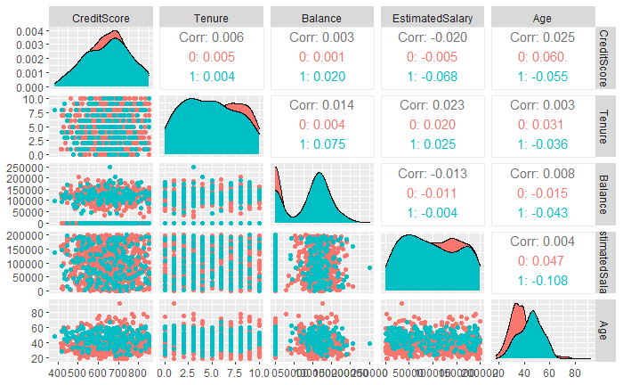

```r
selected_cols <-c("CreditScore","Tenure","Balance","EstimatedSalary","Age")
pairplot <- GGally::ggpairs(data=df,columns = selected_cols,aes(col=as.factor(Exited)))
pairplot
```

On visual inspection it is difficult to ascertain too much meaning from these plots. It should be noted that for almost all of these numeric variables there is some difference between customers who have left (blue) and customers that are retained (red). This is most obvious for the distributions of age in the far right-bottom corner.

### Checking variable continuity

Under normal data cleaning circumstances one should check the continuity of numeric variables. A sudden change may indicate an external effect to the data or missing information.

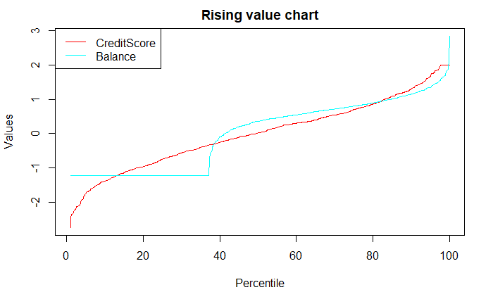

```r
cols <- c("CreditScore", "Balance")
d <- df[,cols]  # select the definitely-continuous columns
for (col in 1:ncol(d)) {
  d[,col] <- d[order(d[,col]),col] #sort each column in ascending order
}
d <- scale(x = d, center = TRUE, scale = TRUE)
mypalette <- rainbow(ncol(d))
matplot(x = seq(1, 100, length.out = nrow(d)), y = d, type = "l", xlab = "Percentile", ylab = "Values", lty = 1, lwd = 1, col = mypalette, main = "Rising value chart")
legend(legend = colnames(d), x = "topleft", y = "top", lty = 1, lwd = 1, col = mypalette, ncol = round(ncol(d)^0.3))
```

There do not appear to be any ‘jumps’ in values for creditscore, however, it is interesting to note that Balance has may zero values. This may affect the modelling process.

### Checking for homogeneity (constant variance)

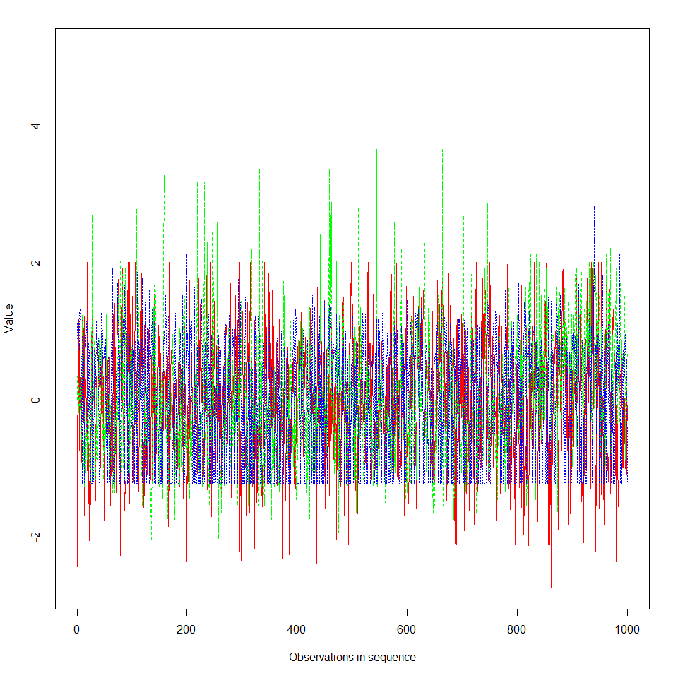

```r
#cols <- c("CreditScore","Tenure","Balance","EstimatedSalary","Age","NumOfProducts") # choose the numeric columns
cols <- c("CreditScore","Age","Balance")
numData <- scale(df[,cols], center = TRUE, scale = TRUE)  ##scaled and centered
matplot(numData, type = "l", col = rainbow(ncol(numData)), xlab = "Observations in sequence", ylab = "Value")
```

Variance over time is reasonably constant.

### boxplots

```
[1] "512"
```

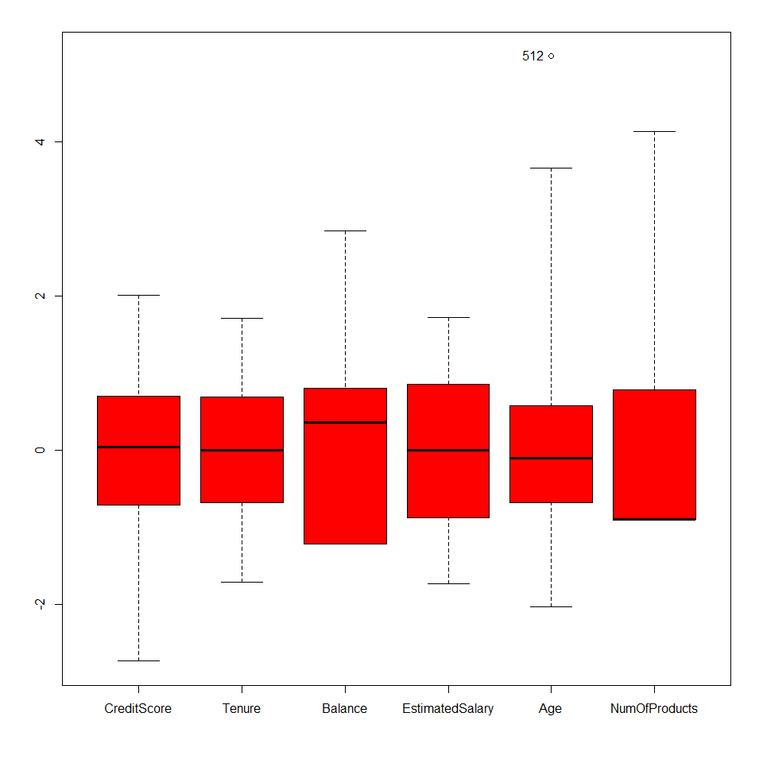

```r
library(car)
criterion <- 3
cols <- c("CreditScore","Tenure","Balance","EstimatedSalary","Age","NumOfProducts") # choose the numeric columns
numData <- scale(df[,cols], center = TRUE, scale = TRUE)
car::Boxplot(numData, range = criterion, col = "red")
```

There are few univariable outliers. Observation 512 is noted for it’s age.

### mutlivariable outliers

```r
dummies <- model.matrix(~ . -observationWeight -1, df) # convert all variables to numeric but exclude the intercept
```

[figure not shown]

Under-representation and over-representaion of ‘country’ in combination with ‘NumOfProducts’ may affect the end result.

## Experiment

A sample of 1000 datapoints were randomly selected from the dataset in the data preparation phase. Observation weighting was incorprated based on the prevalence of the response variable “Exited”. Three methods were assessed and tuned using 10-fold cross validation, repeated 3 times. These methods were Logistic Regression, Support Vector Machines, and a Random Forest.

### Train-test split

Splitting the data using stratified random sampling.

```r
Index <- caret::createDataPartition(y = df$Exited, p = 0.9, list = FALSE) ##stratefoed random split
train <- df[Index,]
test <- df[-Index,]
```

### Support Vector Machines

```r
library(caret)
#specify train control
tc <- trainControl(method = "repeatedcv",
                  repeats = 3,
                   number=10,
                   search="random",
                   )
##train model
mod <- caret::train(Exited ~ . -observationWeight, data = train, weights=train$observationWeight,method = "svmPoly",trControl=tc,verbose=TRUE,tuneLength=30)
```

```r
print(mod)
```

```
Support Vector Machines with Polynomial Kernel

901 samples
 11 predictor
  2 classes: '0', '1'

No pre-processing
Resampling: Cross-Validated (10 fold, repeated 3 times)
Summary of sample sizes: 810, 810, 811, 811, 811, 812, ...
Resampling results across tuning parameters:

  degree  scale         C             Accuracy   Kappa
  1       2.080778e-05    0.24948161  0.7813693  0.0000000
  1       3.433260e-05  707.16769966  0.7813693  0.0000000
  1       8.765933e-05   91.59275182  0.7813693  0.0000000
```

[output cut: 30 more lines]

#### evaluating the training process

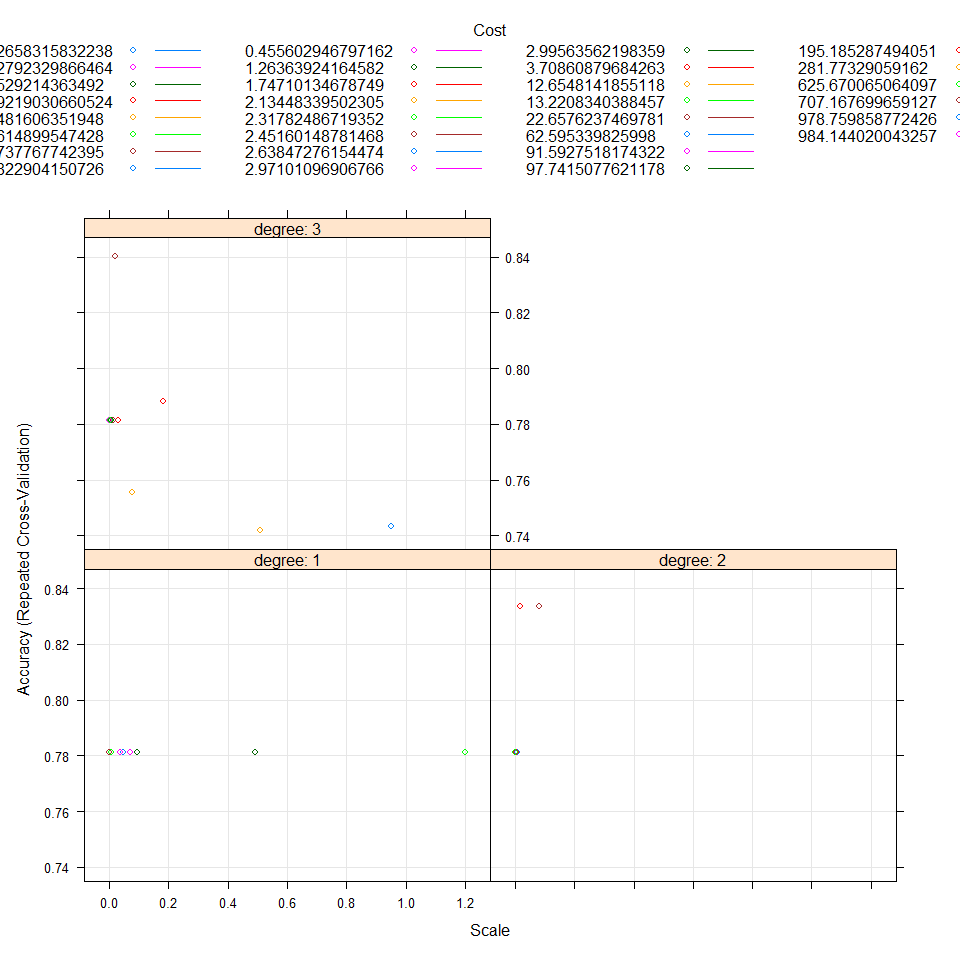

```r
plot(mod,digits=2,plotType="scatter")##try level for a different type of plot
```

#### assessing performance on unseen data

```r
test_preds <- predict(mod, newdata = test)
cm <- confusionMatrix(test_preds, test$Exited)
cm
```

```
Confusion Matrix and Statistics

          Reference
Prediction  0  1
         0 77 14
         1  1  7

               Accuracy : 0.8485
                 95% CI : (0.7624, 0.9126)
    No Information Rate : 0.7879
    P-Value [Acc > NIR] : 0.084444

                  Kappa : 0.4142

 Mcnemar's Test P-Value : 0.001946

            Sensitivity : 0.9872
            Specificity : 0.3333
         Pos Pred Value : 0.8462
         Neg Pred Value : 0.8750
             Prevalence : 0.7879
         Detection Rate : 0.7778
   Detection Prevalence : 0.9192
      Balanced Accuracy : 0.6603

       'Positive' Class : 0
```

#### extracting the best fit

```r
best_params <- mod$bestTune
best_params
```

|  | degree | scale | C |
| --- | --- | --- | --- |
| 25 | 3 | 0.01995779 | 2.451601 |

### logistic regression

```r
library(caret)
#specify train control
tc <- trainControl(method = "repeatedcv",
                  repeats = 3,
                   number=10,
                   search="random",
                   )





##train model
mod <- caret::train(Exited ~ . -observationWeight, data = train, weights=train$observationWeight,method = "glmnet",family="binomial",trControl=tc,verbose=TRUE,tuneLength=30)
```

```r
print(mod)
```

[output not shown]

#### evaluating the training process

```r
plot(mod,digits=2,plotType="scatter")##try level for a different type of plot
```

[output not shown]

#### assessing performance on unseen data

```r
test_preds <- predict(mod, newdata = test)
cm <- confusionMatrix(test_preds, test$Exited)
cm
```

[output not shown]

### Random Forest

```r
#specify train control
tc <- trainControl(method = "repeatedcv",
                  repeats = 3,
                   number=10,
                   search="random",
                   )
##train model
mod <- caret::train(Exited ~ . -observationWeight, data = train, weights=train$observationWeight,method = "rf",trControl=tc,verbose=TRUE,tuneLength=30)
```

```r
print(mod)
```

[output not shown]

#### evaluating the training process

```r
plot(mod,digits=2,plotType="scatter") ##try level for a different type of plot
```

[output not shown]

#### Assessing performance on unseen data

```r
test_preds <- predict(mod, newdata = test)
cm <- confusionMatrix(test_preds, test$Exited)
cm
```

[output not shown]

### Model Visualisation

```r
##creating an alluvial chart
library(alluvial)
data <- as.data.frame(cm$table)
data$Colour = ifelse(data$Prediction == data$Reference, "green", "red")
par(mar = c(0,0,1,0))
alluvial::alluvial(
  data[,c("Reference","Prediction")],
  freq = data$Freq,
  col = data$Colour,
  alpha = 0.5,
  hide = data$Freq == 0
)

geomtext("Classification of Customer Churn", font = 2)
```

[output not shown]

#### visualising variable importance

```r
plot(caret::varImp(object = mod))
```

[output not shown]

```r
##support vector machine
library(e1071)
fit <- svm(Exited ~ NumOfProducts + CreditScore + Geography + Gender + Age + Balance + Tenure + HasCrCard + IsActiveMember + EstimatedSalary,
           data = train,
           scale = 0.15,
           kernel = "polynomial",
           degree=3,
           cost = 38)

##visualising support vector decision boundary in the 2 most important dimensions
##light blue corresponds to pointst that are actually Exited
plot(fit,data=test,Balance~Age,svSymbol = 1, dataSymbol = 2,symbolPalette = rainbow(2),fill=TRUE) ##plotting the decision boundary on test, 0 sybols are support vectors
```

[output not shown]